```python
import matplotlib.pyplot as plt
import pandas as pd
import numpy as np
from sklearn.model_selection import train_test_split
from sklearn.tree import DecisionTreeClassifier, export_text, plot_tree
from sklearn.ensemble import RandomForestClassifier
from sklearn.preprocessing import OneHotEncoder

%matplotlib inline
```

```python
df = pd.read_csv("online_shoppers_intention.csv")
```

# Question 1

```python
df['Revenue'].value_counts()
```

```
False    10422
True      1908
Name: Revenue, dtype: int64
```

```python
df.describe()
```

|  | Administrative | Administrative_Duration | Informational | Informational_Duration | ProductRelated | ProductRelated_Duration | BounceRates | ExitRates | PageValues | SpecialDay | OperatingSystems | Browser | Region | TrafficType |
| --- | --- | --- | --- | --- | --- | --- | --- | --- | --- | --- | --- | --- | --- | --- |
| count | 12330.000000 | 12330.000000 | 12330.000000 | 12330.000000 | 12330.000000 | 12330.000000 | 12330.000000 | 12330.000000 | 12330.000000 | 12330.000000 | 12330.000000 | 12330.000000 | 12330.000000 | 12330.000000 |
| mean | 2.315166 | 80.818611 | 0.503569 | 34.472398 | 31.731468 | 1194.746220 | 0.022191 | 0.043073 | 5.889258 | 0.061427 | 2.124006 | 2.357097 | 3.147364 | 4.069586 |
| std | 3.321784 | 176.779107 | 1.270156 | 140.749294 | 44.475503 | 1913.669288 | 0.048488 | 0.048597 | 18.568437 | 0.198917 | 0.911325 | 1.717277 | 2.401591 | 4.025169 |
| min | 0.000000 | 0.000000 | 0.000000 | 0.000000 | 0.000000 | 0.000000 | 0.000000 | 0.000000 | 0.000000 | 0.000000 | 1.000000 | 1.000000 | 1.000000 | 1.000000 |
| 25% | 0.000000 | 0.000000 | 0.000000 | 0.000000 | 7.000000 | 184.137500 | 0.000000 | 0.014286 | 0.000000 | 0.000000 | 2.000000 | 2.000000 | 1.000000 | 2.000000 |
| 50% | 1.000000 | 7.500000 | 0.000000 | 0.000000 | 18.000000 | 598.936905 | 0.003112 | 0.025156 | 0.000000 | 0.000000 | 2.000000 | 2.000000 | 3.000000 | 2.000000 |
| 75% | 4.000000 | 93.256250 | 0.000000 | 0.000000 | 38.000000 | 1464.157214 | 0.016813 | 0.050000 | 0.000000 | 0.000000 | 3.000000 | 2.000000 | 4.000000 | 4.000000 |
| max | 27.000000 | 3398.750000 | 24.000000 | 2549.375000 | 705.000000 | 63973.522230 | 0.200000 | 0.200000 | 361.763742 | 1.000000 | 8.000000 | 13.000000 | 9.000000 | 20.000000 |

```python
df_no_buy = df[df['Revenue'] == False]
df_buy = df[df['Revenue'] == True]

data = [df_no_buy, df_buy]

#Looking at number of visits made total
print(sum(df_no_buy['SpecialDay'].value_counts()))
print(sum(df_buy['SpecialDay'].value_counts()))
```

```
10422
1908
```

```python
#Looking at number of visits made near special days
print(sum(df_no_buy[df['SpecialDay'] != 0]['SpecialDay'].value_counts()))
print(sum(df_buy[df['SpecialDay'] != 0]['SpecialDay'].value_counts()))
```

```
1174
77
```

```python
#Percentage of total visits occuring on special days
percent_specialdays_buy = 100 * (sum(df_buy[df['SpecialDay'] != 0]['SpecialDay'].value_counts()) / sum(df_buy['SpecialDay'].value_counts()))
percent_specialdays_nobuy = 100 * (sum(df_no_buy[df['SpecialDay'] != 0]['SpecialDay'].value_counts()) / sum(df_no_buy['SpecialDay'].value_counts()))

percent_specialdays = 100 *  (sum(df[df['SpecialDay'] != 0]['SpecialDay'].value_counts()) / sum(df['SpecialDay'].value_counts()))
print(percent_specialdays_buy)
print(percent_specialdays_nobuy)
print(percent_specialdays)
```

```
4.035639412997904
11.264632508155824
10.145985401459855
```

```python
#Looking at percentage of purchases made on weekends
print(df_buy['Weekend'].value_counts() / df_buy['Weekend'].count())
print(df_no_buy['Weekend'].value_counts() / df_no_buy['Weekend'].count())
```

```
False    0.73847
True     0.26153
Name: Weekend, dtype: float64
False    0.772692
True     0.227308
Name: Weekend, dtype: float64
```

Looking at disitribution of bounce rates

```
{'whiskers': [<matplotlib.lines.Line2D at 0x27a3d269b20>,
 'caps': [<matplotlib.lines.Line2D at 0x27a3d27a100>,
 'boxes': [<matplotlib.lines.Line2D at 0x27a3d269850>,
 'medians': [<matplotlib.lines.Line2D at 0x27a3d27a6a0>,
 'fliers': [<matplotlib.lines.Line2D at 0x27a3d25bc40>,
 'means': []}
```

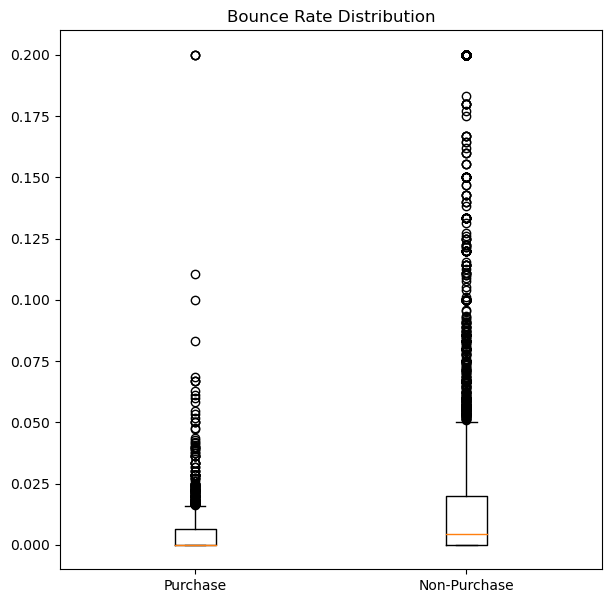

```python
fig = plt.figure(figsize=(7,7))
ax = fig.add_subplot(111)

data = [df_buy['BounceRates'], df_no_buy['BounceRates']]
df_buy
ax.set_title("Bounce Rate Distribution")
ax.set_xticklabels(['Purchase', 'Non-Purchase'])
ax.boxplot(data)
```

```python
data[0].mean()
```

```
0.005117152640461212
```

```python
data[1].mean()
```

```
0.025317232197850356
```

Looking at exit rate distribution

```
{'whiskers': [<matplotlib.lines.Line2D at 0x27a3d304e50>,
 'caps': [<matplotlib.lines.Line2D at 0x27a3d30d430>,
 'boxes': [<matplotlib.lines.Line2D at 0x27a3d304b80>,
 'medians': [<matplotlib.lines.Line2D at 0x27a3d2fecd0>,
 'fliers': [<matplotlib.lines.Line2D at 0x27a3d2fe580>,
 'means': []}
```

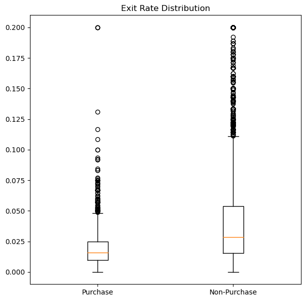

```python
fig = plt.figure(figsize=(7,7))
ax = fig.add_subplot(111)

data = [df_buy['ExitRates'], df_no_buy['ExitRates']]
ax.set_title("Exit Rate Distribution")
ax.set_xticklabels(['Purchase', 'Non-Purchase'])
ax.boxplot(data)
```

```python
data[0].mean()
```

```
0.019555168256813433
```

```python
data[1].mean()
```

```
0.04737827052648154
```

Number of pages visited

```python
df['TotalPages'] = df["Administrative"] + df["Informational"] + df["ProductRelated"]
df_buy['TotalPages'] = df_buy["Administrative"] + df_buy["Informational"] + df_buy["ProductRelated"]
df_no_buy['TotalPages'] = df_no_buy["Administrative"] + df_no_buy["Informational"] + df_no_buy["ProductRelated"]
```

```python
print(df_buy['TotalPages'].mean())
print(df_no_buy['TotalPages'].mean())
```

```
52.38993710691824
31.284206486279025
```

People who purchase a product from the site visit an average of 20 (!) more pages.

```
{'whiskers': [<matplotlib.lines.Line2D at 0x27a3d39dac0>,
 'caps': [<matplotlib.lines.Line2D at 0x27a3d3a90a0>,
 'boxes': [<matplotlib.lines.Line2D at 0x27a3d39d7f0>,
 'medians': [<matplotlib.lines.Line2D at 0x27a3d3a9640>,
 'fliers': [<matplotlib.lines.Line2D at 0x27a3d3a9910>,
 'means': []}
```

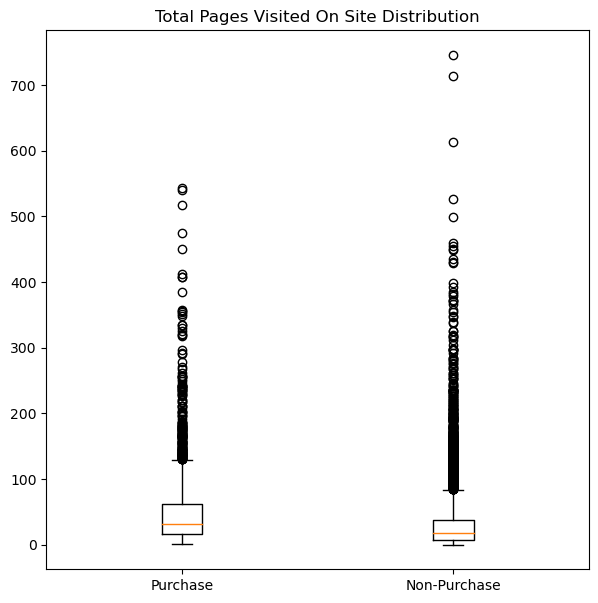

```python
fig = plt.figure(figsize=(7,7))
ax = fig.add_subplot(111)

data = [df_buy['TotalPages'], df_no_buy['TotalPages']]
ax.set_xticklabels(['Purchase', 'Non-Purchase'])
ax.set_title("Total Pages Visited On Site Distribution")
ax.boxplot(data)
```

Seeing if month has anything to do with sales

```python
df['Month'].value_counts()
```

```
May     3364
Nov     2998
Mar     1907
Dec     1727
Oct      549
Sep      448
Aug      433
Jul      432
June     288
Feb      184
Name: Month, dtype: int64
```

```python
df_buy['Month'].value_counts()
```

```
Nov     760
May     365
Dec     216
Mar     192
Oct     115
Sep      86
Aug      76
Jul      66
June     29
Feb       3
Name: Month, dtype: int64
```

```python
df_no_buy['Month'].value_counts()
```

```
May     2999
Nov     2238
Mar     1715
Dec     1511
Oct      434
Jul      366
Sep      362
Aug      357
June     259
Feb      181
Name: Month, dtype: int64
```

```python
100 * df_buy['Month'].value_counts() / df['Month'].value_counts()
```

```
Aug     17.551963
Dec     12.507238
Feb      1.630435
Jul     15.277778
June    10.069444
Mar     10.068170
May     10.850178
Nov     25.350233
Oct     20.947177
Sep     19.196429
Name: Month, dtype: float64
```

Total time spent looking at pages

```python
df['TotalTime'] = df["Administrative_Duration"] + df["Informational_Duration"] + df["ProductRelated_Duration"]

df_buy['TotalTime'] = df_buy["Administrative_Duration"] + df_buy["Informational_Duration"] + df_buy["ProductRelated_Duration"]
df_no_buy['TotalTime'] = df_no_buy["Administrative_Duration"] + df_no_buy["Informational_Duration"] + df_no_buy["ProductRelated_Duration"]
```

```python
print(df_buy['TotalTime'].mean())
print(df_no_buy['TotalTime'].mean())
```

```
2053.3042854341525
1173.9641575519258
```

Site visits that end in purchase are usually TWICE as long as visits that do not end in purchase.

```
{'whiskers': [<matplotlib.lines.Line2D at 0x27a3d43a3a0>,
 'caps': [<matplotlib.lines.Line2D at 0x27a3d43a940>,
 'boxes': [<matplotlib.lines.Line2D at 0x27a3d43a0d0>,
 'medians': [<matplotlib.lines.Line2D at 0x27a3d42df70>,
 'fliers': [],
 'means': []}
```

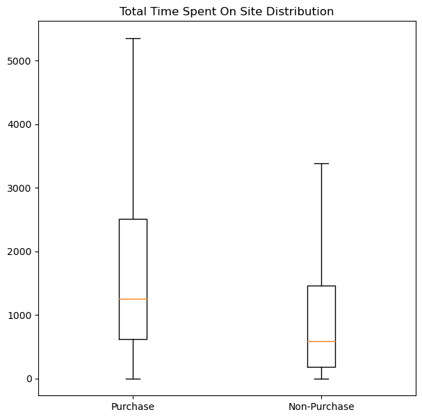

```python
fig = plt.figure(figsize=(7,7))
ax = fig.add_subplot(111)

data = [df_buy['TotalTime'], df_no_buy['TotalTime']]
ax.set_xticklabels(['Purchase', 'Non-Purchase'])
ax.set_title("Total Time Spent On Site Distribution")
ax.boxplot(data, showfliers=False)
```

Finally, looking at what percentage of returning visitors and new visitors made a purchase

```python
total_returning_visitors = df[df['VisitorType'] == 'Returning_Visitor']['VisitorType'].count()
total_new_visitors = df[df['VisitorType'] == 'New_Visitor']['VisitorType'].count()

print(total_returning_visitors)
print(total_new_visitors)
```

```
10551
1694
```

```python
buying_returning_visitors = df_buy[df_buy['VisitorType'] == 'Returning_Visitor']['VisitorType'].count()
buying_new_visitors = df_buy[df_buy['VisitorType'] == 'New_Visitor']['VisitorType'].count()

print(buying_returning_visitors)
print(buying_new_visitors)
```

```
1470
422
```

```python
percent_returning_visitors_buy = 100 * buying_returning_visitors / total_returning_visitors
percent_new_visitors_buy = 100 * buying_new_visitors / total_new_visitors

print(percent_returning_visitors_buy)
print(percent_new_visitors_buy)
```

```
13.93232868922377
24.911452184179456
```

It seems there is a correlation between: -Bounce Rate -Exit Rate -Total Pages Visited -Total Time Spent On Site -Month Of Year -Whether The Visitor Is New Or Returning

# Question 2

```python
labels = pd.DataFrame()
enc = OneHotEncoder()
transformed = enc.fit_transform(df[["Revenue"]])
print(transformed.toarray())
print(enc.categories_[0])
#labels[enc.categories_[0]] = transformed.toarray()
#print(labels)
```

```
[[1. 0.]
 [1. 0.]
 [1. 0.]
 ...
 [1. 0.]
 [1. 0.]
 [1. 0.]]
[False  True]
```

```python
features = pd.DataFrame()
df['VisitorType'].replace(('Returning_Visitor', 'New_Visitor', 'Other'), (0,1,2), inplace=True)
df['Month'].replace(('Feb', 'Mar', 'May', 'June', 'Jul', 'Aug', 'Sep', 'Oct', 'Nov', 'Dec'), (0,1,2,3,4,5,6,7,8,9), inplace=True)
df['Revenue'].replace((False, True), (0,1), inplace=True)
features['TotalPages'] = df['TotalPages']
features['TotalTime'] = df['TotalTime']
features['BounceRates'] = df['BounceRates']
features['ExitRates'] = df['ExitRates']
features['VisitorType'] = df['VisitorType']
features['Month'] = df['Month']
#label = pd.DataFrame(transformed.toarray())
label = df['Revenue']

#print(features)
#print(label)

x_train, x_test_original, y_train, y_test_original = train_test_split(features, label, stratify=label)
```

```
[Text(0.5980337992210941, 0.9857142857142858, 'X[3] <= 0.029\ngini = 0.262\nsamples = 9247\nvalue = [7816, 1431]'),
 ...]
```

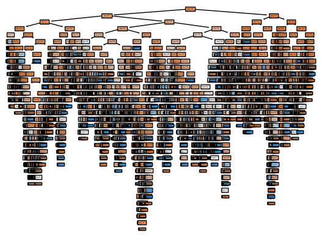

```python
model = DecisionTreeClassifier(
    criterion="gini",
    splitter='best',
    random_state=0,
    )

model.fit(x_train, y_train)
plot_tree(model, filled=True)
```

```python
print(model.score(x_test, y_test))
```

```
0.776192020759001
```

```python
from sklearn.metrics import accuracy_score, confusion_matrix, classification_report
```

```python
model_random = RandomForestClassifier(
    n_estimators=100,
    criterion="gini",
    random_state=0,
    min_samples_split=10
    )
model_random.fit(x_train, y_train)
```

```
RandomForestClassifier(min_samples_split=10, random_state=0)
```

```python
print(model_random.score(x_test, y_test))

y_pred = model_random.predict(x_test)
print(confusion_matrix(y_test.to_numpy(), y_pred))
```

```
0.8433344145313006
[[2551   55]
 [ 428   49]]
```

```python
print(classification_report(y_test.to_numpy(), y_pred))
```

```
              precision    recall  f1-score   support

           0       0.86      0.98      0.91      2606
           1       0.47      0.10      0.17       477

    accuracy                           0.84      3083
   macro avg       0.66      0.54      0.54      3083
weighted avg       0.80      0.84      0.80      3083
```

```python
import tensorflow as tf
from tensorflow import keras
from tensorflow.keras import layers
from sklearn import preprocessing
from sklearn.metrics import plot_confusion_matrix
```

```python
#x_train = preprocessing.normalize(x_train)
#x_test = preprocessing.normalize(x_test)

model_neural = keras.Sequential([
    layers.Dense(100, activation='relu'),
    layers.Dense(100, activation='relu'),
    layers.Dense(100, activation='relu'),
    layers.Dense(1, activation='sigmoid')
])

model_neural.compile(optimizer="Adam",
              loss='binary_crossentropy',
              metrics=['accuracy', keras.metrics.Recall(), keras.metrics.FalsePositives(), keras.metrics.FalseNegatives(), keras.metrics.TruePositives(), keras.metrics.TrueNegatives(), tf.keras.metrics.BinaryAccuracy(
    name='binary_accuracy', dtype=None, threshold=0.2
)])
```

```python
y_train.value_counts()
```

```
0    7816
1    1431
Name: Revenue, dtype: int64
```

```python
y_train.shape
```

```
(9247,)
```

```python
from tensorflow.keras.callbacks import EarlyStopping
stop = EarlyStopping(monitor='loss',
                                   mode='max',
                                   patience=10,
                                   restore_best_weights=True)

history = model_neural.fit(x_train,
                    y_train,
                    callbacks=[stop],
                    epochs=20,
                    batch_size=1,
                    validation_split=0.2,
                    shuffle=True,
                    verbose=1)
```

```python
model_neural.evaluate(x_test, y_test)
print(y_train.value_counts())
print(y_test.value_counts())
```

```
0    7816
1    1431
Name: Revenue, dtype: int64
0    2606
1     477
Name: Revenue, dtype: int64
```

```python
y_pred = model_neural.predict(x_test)

print(y_test[0:30])
print(y_pred[0:30])
```

```
263      0
2578     0
8569     0
7882     0
4633     0
9843     1
11736    0
5192     0
11278    0
6992     0
9801     0
11351    1
4540     0
10318    1
8986     0
10649    0
10175    0
6517     0
4163     0
4902     1
7070     0
11469    0
11491    0
8963     0
8627     1
3606     0
7790     0
7114     0
5346     0
11541    1
Name: Revenue, dtype: int64
[[0.17867287]
 [0.2046506 ]
 [0.20483756]
 [0.11950065]
 [0.1983472 ]
 [0.19893187]
 [0.21691985]
 [0.21151857]
 [0.20568304]
 [0.20663863]
 [0.21683687]
 [0.21803065]
 [0.2092311 ]
 [0.21159479]
 [0.21120091]
 [0.19037269]
 [0.20852506]
 [0.15956986]
 [0.00446723]
 [0.196883  ]
 [0.2135739 ]
 [0.20037615]
 [0.20733336]
 [0.1391567 ]
 [0.22245087]
 [0.14052297]
 [0.20452298]
 [0.20571493]
 [0.20842625]
 [0.21843944]]
```

The model is only classifying data as a non-purchase, which is obviously not the case

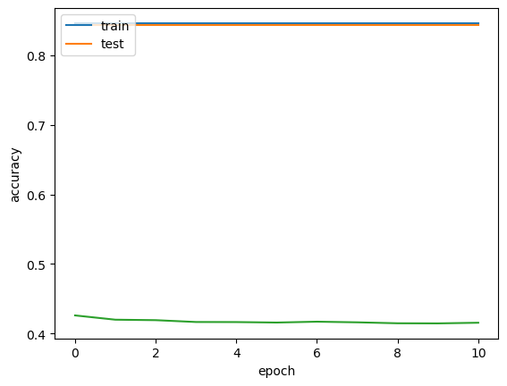

```python
plt.plot(history.history['accuracy'])
plt.plot(history.history['val_accuracy'])
plt.plot(history.history['loss'])
plt.ylabel('accuracy')
plt.xlabel('epoch')
plt.legend(['train', 'test'], loc='upper left')
```

Now to implement imblearn and conduct the same experiment on the over sampled data.

```python
from imblearn.over_sampling import RandomOverSampler
```

```python
ros = RandomOverSampler(random_state=0)
```

```python
x = features
y = label

features_resampled, label_resampled = ros.fit_resample(x, y)
```

```python
label_resampled.value_counts()
```

```
0    10422
1    10422
Name: Revenue, dtype: int64
```

```
[Text(0.6726851294453481, 0.9848484848484849, 'X[3] <= 0.04\ngini = 0.5\nsamples = 15633\nvalue = [7817, 7816]'),
 ...]
```

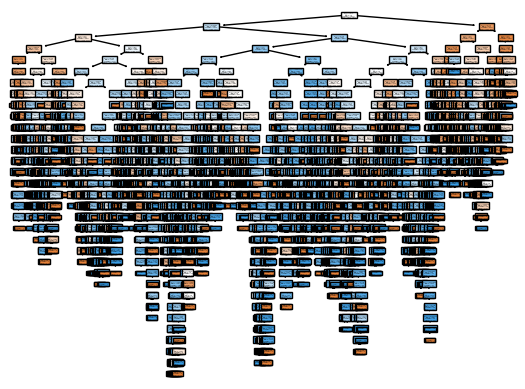

```python
x_train, x_test, y_train, y_test = train_test_split(features_resampled, label_resampled, stratify=label_resampled)

model = DecisionTreeClassifier(
    criterion="gini",
    splitter='best',
    random_state=0,
    )

model.fit(x_train, y_train)
plot_tree(model, filled=True)
```

```python
print(model.score(x_test, y_test))
```

```
0.9092304739973134
```

```python
y_pred = model.predict(x_test)
print(classification_report(y_test.to_numpy(), y_pred))
```

```
              precision    recall  f1-score   support

           0       0.98      0.83      0.90      2605
           1       0.85      0.99      0.92      2606

    accuracy                           0.91      5211
   macro avg       0.92      0.91      0.91      5211
weighted avg       0.92      0.91      0.91      5211
```

```python
model_random = RandomForestClassifier(
    n_estimators=100,
    criterion="gini",
    random_state=1,
    min_samples_split=2
    )
model_random.fit(x_train, y_train)
```

```
RandomForestClassifier(random_state=1)
```

```python
print(model_random.score(x_test, y_test))

y_pred = model_random.predict(x_test)
print(confusion_matrix(y_test.to_numpy(), y_pred))
```

```
0.9397428516599501
[[2318  287]
 [  27 2579]]
```

```python
print(classification_report(y_test.to_numpy(), y_pred))
```

```
              precision    recall  f1-score   support

           0       0.99      0.89      0.94      2605
           1       0.90      0.99      0.94      2606

    accuracy                           0.94      5211
   macro avg       0.94      0.94      0.94      5211
weighted avg       0.94      0.94      0.94      5211
```

Now with min_samples_split=10

```python
model_random_2 = RandomForestClassifier(
    n_estimators=100,
    criterion="gini",
    random_state=0,
    min_samples_split=10
    )
model_random_2.fit(x_train, y_train)
```

```
RandomForestClassifier(min_samples_split=10, random_state=0)
```

```python
print(model_random_2.score(x_test, y_test))

y_pred = model_random_2.predict(x_test)
print(confusion_matrix(y_test.to_numpy(), y_pred))

print(classification_report(y_test.to_numpy(), y_pred))
```

```
0.9126847054308194
[[2246  359]
 [  96 2510]]
              precision    recall  f1-score   support

           0       0.96      0.86      0.91      2605
           1       0.87      0.96      0.92      2606

    accuracy                           0.91      5211
   macro avg       0.92      0.91      0.91      5211
weighted avg       0.92      0.91      0.91      5211
```

```python
#x_train = preprocessing.normalize(x_train)
#x_test = preprocessing.normalize(x_test)

model_neural = keras.Sequential([
    layers.Dense(100, activation='relu'),
    layers.Dense(100, activation='relu'),
    layers.Dense(100, activation='relu'),
    layers.Dense(1, activation='sigmoid')
])

model_neural.compile(optimizer="Adam",
              loss='binary_crossentropy',
              metrics=['accuracy', keras.metrics.Recall(), keras.metrics.FalsePositives(), keras.metrics.FalseNegatives(), keras.metrics.TruePositives(), keras.metrics.TrueNegatives()])
```

```python
from tensorflow.keras.callbacks import EarlyStopping
stop = EarlyStopping(monitor='loss',
                                   mode='max',
                                   patience=10,
                                   restore_best_weights=True)

history = model_neural.fit(x_train,
                    y_train,
                    callbacks=[stop],
                    epochs=20,
                    batch_size=1,
                    validation_split=0.2,
                    shuffle=True,
                    verbose=1)
```

```python
model_neural.evaluate(x_test, y_test)
print(y_train.value_counts())
print(y_test.value_counts())
```

```
0    7817
1    7816
Name: Revenue, dtype: int64
1    2606
0    2605
Name: Revenue, dtype: int64
```

Just to check, I used the original test data (the test data before oversampling) to make predictions. These are the results.

```python
print(model.score(x_test_original, y_test_original))
y_pred = model.predict(x_test_original)
print(classification_report(y_test_original.to_numpy(), y_pred))
```

```
0.967239701589361
              precision    recall  f1-score   support

           0       1.00      0.96      0.98      2606
           1       0.83      1.00      0.90       477

    accuracy                           0.97      3083
   macro avg       0.91      0.98      0.94      3083
weighted avg       0.97      0.97      0.97      3083
```

```python
print(model_random.score(x_test_original, y_test_original))

y_pred = model_random.predict(x_test_original)
print(confusion_matrix(y_test_original.to_numpy(), y_pred))
```

```
0.9769704832954914
[[2535   71]
 [   0  477]]
```

```python
print(classification_report(y_test_original.to_numpy(), y_pred))
```

```
              precision    recall  f1-score   support

           0       1.00      0.97      0.99      2606
           1       0.87      1.00      0.93       477

    accuracy                           0.98      3083
   macro avg       0.94      0.99      0.96      3083
weighted avg       0.98      0.98      0.98      3083
```